# progetto_air_crashes

```python
lng_list, lat_list = [], []
lat_list = []
for lat, lng in locs:
    lat_list.append(lat)
    lng_list.append(lng)
```

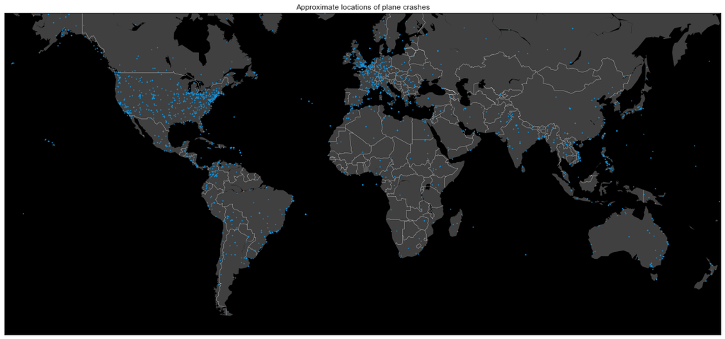

```python
base_map = Basemap(projection='merc', llcrnrlat=-60, urcrnrlat=65, llcrnrlon=-180, urcrnrlon=180)

plt.figure(figsize=(20, 10))

base_map.fillcontinents(color='#404040', lake_color='#000000')
base_map.drawmapboundary(fill_color='#000000')
base_map.drawcountries(linewidth=0.3, color="w")

mxy = base_map(lng_list, lat_list)
base_map.scatter(mxy[0], mxy[1], s=3, c="#1292db", lw=0, alpha=1, zorder=5)

plt.title("Approximate locations of plane crashes")
plt.show()
```

```python
fig = go.Figure(data=go.Scattergeo(
        lon = lng_list,
        lat = lat_list,
        text = "",
        mode = 'markers'

        ))

fig.update_layout(
        title = 'Approximate locations of plane crashes',
        geo_scope='world',
    )
fig.show()
```

[interactive chart not shown]

### 7.1 Analizziamo le rotte con il totale numero di vittime più alto

```python
route= dataset.groupby('Route').agg({'Fatalities':['sum',lambda x:x.sum() / dataset['Fatalities'].sum()]})
route.columns=route.columns.map(''.join)
route.reset_index(inplace=True)
route.rename(columns={'Fatalitiessum':'Total Fatalities','Fatalities<lambda>':'% of Total Fatalities'}, inplace=True)

route.sort_values(by='Total Fatalities', ascending=False).head(7)
```

|  | Route | Total Fatalities | % of Total Fatalities |
| --- | --- | --- | --- |
| 3548 | Training | 736.0 | 0.006644 |
| 3468 | Tenerife - Las Palmas / Tenerife - Las Palmas | 583.0 | 0.005263 |
| 3520 | Tokyo - Osaka | 557.0 | 0.005028 |
| 2684 | Paris - London | 387.0 | 0.003494 |
| 2437 | New Delhi - Dhahran / Chimkent - New Delhi | 349.0 | 0.003151 |
| 2312 | Montreal - London | 329.0 | 0.002970 |
| 2956 | Riyadh - Jeddah | 301.0 | 0.002717 |

### 7.2 Analizziamo i luoghi più pericolosi per volare

```python
from collections import Counter
loc_list = Counter(dataset['Location'].dropna()).most_common(10)
locs = []
crashes = []
for loc in loc_list:
    locs.append(loc[0])
    crashes.append(loc[1])
pd.DataFrame({'Crashes in this location' : crashes}, index=locs)
```

|  | Crashes in this location |
| --- | --- |
| Moscow, Russia | 17 |
| New York, New York | 14 |
| Manila, Philippines | 14 |
| Cairo, Egypt | 13 |
| Sao Paulo, Brazil | 13 |
| Rio de Janeiro, Brazil | 12 |
| Bogota, Colombia | 12 |
| Chicago, Illinois | 11 |
| Near Moscow, Russia | 11 |
| Tehran, Iran | 10 |

## Conclusioni

- Non volare con Aeroflot, c'è più probabilità che tu muoia.
- Non salire a bordo di un Douglas DC-3, questo aereo ha la più alta percentuale di incidenti
- Meglio se non vai a Mosca, New York, Manila e Cairo, sono i luoghi con il maggior numero di incidenti aerei.
- Oggi è molto più sicuro prendere il volo rispetto al passato, gli anni 1945 e 1989 sono stati i peggiori nella storia dell'avviazione civile e militare.